# Tugas 3

Davina Rachmadyanti

2023-09-12

Packages

```r
library(dLagM)
library(dynlm)
library(MLmetrics)
library(lmtest)
```

### Data

```r
data <- rio::import("https://raw.githubusercontent.com/davinarachmadyanti/mpdw/main/Petemuan%203/newdelhi_aqi.csv")
str(data)
```

```
## 'data.frame':    72 obs. of  12 variables:
##  $ V1             : int  0 1 2 3 4 5 6 7 8 9 ...
##  $ AQI            : num  30.2 28.2 26.6 25 26 26 26 24 23 24 ...
##  $ CO             : num  199 198 199 202 205 ...
##  $ datetime       : chr  "2022-10-21:18" "2022-10-21:19" "2022-10-21:20" "2022-10-21:21" ...
##  $ no2            : num  0.0469 0.0465 0.0469 0.0482 0.0489 ...
##  $ o3             : num  55.8 54.9 54.6 55.1 55.8 ...
##  $ pm10           : num  10.5 10.7 11.2 11.1 10.4 ...
##  $ pm25           : num  5.64 4.62 3.52 2.23 1.98 ...
##  $ so2            : num  0.387 0.41 0.402 0.376 0.339 ...
##  $ timestamp_local: POSIXct, format: "2022-10-21 23:00:00" "2022-10-22 00:00:00" ...
##  $ timestamp_utc  : POSIXct, format: "2022-10-21 18:00:00" "2022-10-21 19:00:00" ...
##  $ ts             : int  1666375200 1666378800 1666382400 1666386000 1666389600 1666393200 1666396800 1666400400 1666404000 1666407600 ...
```

```r
data
```

```
##    V1  AQI       CO      datetime        no2       o3      pm10     pm25
## 1   0 30.2 198.6027 2022-10-21:18 0.04685717 55.78995 10.486722 5.637410
## 2   1 28.2 197.6013 2022-10-21:19 0.04645554 54.93164 10.719325 4.618169
## 3   2 26.6 198.6027 2022-10-21:20 0.04685717 54.64554 11.155578 3.520902
## 4   3 25.0 201.9405 2022-10-21:21 0.04819594 55.07469 11.116206 2.225919
## 5   4 26.0 205.2784 2022-10-21:22 0.04886533 55.78995 10.405250 1.979471
## 6   5 26.0 208.6163 2022-10-21:23 0.05020411 56.50520  9.402518 1.792677
## 7   6 26.0 208.6163 2022-10-22:00 0.05020411 55.78995  8.482822 1.752237
## 8   7 24.0 205.2784 2022-10-22:01 0.05020411 52.92892  7.586667 1.858459
## 9   8 23.0 200.2716 2022-10-22:02 0.04685717 50.06790  7.636587 2.208076
## 10  9 24.0 196.9338 2022-10-22:03 0.04417961 51.49841  8.487648 2.476681
## 11 10 25.0 198.6027 2022-10-22:04 0.04284084 53.64418  9.357371 2.585729
## 12 11 26.0 200.2716 2022-10-22:05 0.04049798 55.78995 10.338728 2.390081
## 13 12 27.0 203.6095 2022-10-22:06 0.04016329 59.36623 10.523314 2.086022
## 14 13 29.0 205.2784 2022-10-22:07 0.03882451 62.22725 10.635970 1.937047
```

[output cut: 131 more lines]

```r
data = cbind(data$AQI,data$so2)
data = as.data.frame(data)
colnames(data) = c("AQI","SO2")
data
```

```
##     AQI       SO2
## 1  30.2 0.3874302
## 2  28.2 0.4097819
## 3  26.6 0.4023313
## 4  25.0 0.3762543
## 5  26.0 0.3390014
## 6  26.0 0.3129244
## 7  26.0 0.3129244
## 8  24.0 0.3427267
## 9  23.0 0.3948808
## 10 24.0 0.4284084
## 11 25.0 0.4284084
## 12 26.0 0.3986061
## 13 27.0 0.3501773
## 14 29.0 0.3166497
```

[output cut: 58 more lines]

```r
#data <- rio::import("https://raw.githubusercontent.com/rizkynurhambali/Praktikum-MPDW-2324/main/Pertemuan%203/Data%20Asli.csv")
#str(data)
#data
```

Pembagian Data

```r
#SPLIT DATA
train<-data[1:57,] #80% dari data
test<-data[58:72,] #20% dari data
```

Menjadikan data sebagai data time series

```r
#data time series
train.ts<-ts(train)
test.ts<-ts(test)
data.ts<-ts(data)
```

## Model Koyck

Model Koyck didasarkan pada asumsi bahwa semakin jauh jarak lag peubah independen dari periode sekarang maka semakin kecil pengaruh peubah lag terhadap peubah dependen.

Koyck mengusulkan suatu metode untuk menduga model dinamis distributed lag dengan mengasumsikan bahwa semua koefisien $\beta$ mempunyai tanda sama.

Model kyock merupakan jenis paling umum dari model infinite distributed lag dan juga dikenal sebagai geometric lag

$$y_t=a(1-\lambda)+\beta_0X_t+\beta_1Z_t+\lambda Y_{t-1}+V_t$$

dengan
$$V_t=u_t-\lambda
u_{t-1}$$

### Pemodelan Koyck

Pemodelan model Koyck dengan `R` dapat menggunakan `dLagM::koyckDlm()` . Fungsi umum dari `koyckDlm` adalah sebagai berikut.

```r
koyckDlm(x , y , intercept)
```

Fungsi `koyckDlm()` akan menerapkan model lag terdistribusi dengan transformasi Koyck satu prediktor. Nilai `x` dan `y` tidak perlu sebagai objek *time series* (`ts`). `intercept` dapat dibuat `TRUE` untuk memasukkan intersep ke dalam model.

```r
#MODEL KOYCK
model.koyck <- koyckDlm(x = train$SO2, y = train$AQI)
summary(model.koyck)
```

```
##
## Call:
## "Y ~ (Intercept) + Y.1 + X.t"
##
## Residuals:
##      Min       1Q   Median       3Q      Max
## -2.03389 -0.64933  0.06714  0.59821  2.27449
##
## Coefficients:
##             Estimate Std. Error t value Pr(>|t|)
## (Intercept)  2.65074    3.25695   0.814    0.419
## Y.1          0.89806    0.07378  12.171   <2e-16 ***
## X.t          0.09810    4.59272   0.021    0.983
## ---
## Signif. codes:  0 '***' 0.001 '**' 0.01 '*' 0.05 '.' 0.1 ' ' 1
##
## Residual standard error: 0.9316 on 53 degrees of freedom
## Multiple R-Squared: 0.8176,  Adjusted R-squared: 0.8108
## Wald test: 118.9 on 2 and 53 DF,  p-value: < 2.2e-16
##
## Diagnostic tests:
## NULL
##
##                             alpha       beta       phi
## Geometric coefficients:  26.00265 0.09809751 0.8980589
```

### Peramalan dan Akurasi Model Koyck

Berikut adalah hasil peramalan y untuk 15 periode kedepan menggunakan model koyck

```r
#h =15, merupakan 15 periode yang akan diprediksi selanjutnya
fore.koyck <- forecast(model = model.koyck, x=test$SO2, h=15)
fore.koyck
```

```
## $forecasts
##  [1] 25.14424 25.27523 25.39397 25.50060 25.59600 25.68058 25.75470 25.82018
##  [9] 25.87861 25.93036 25.97610 26.01645 26.05195 26.08347 26.11141
##
## $call
## forecast.koyckDlm(model = model.koyck, x = test$SO2, h = 15)
##
## attr(,"class")
## [1] "forecast.koyckDlm" "dLagM"
```

```r
#akurasi data testing
mape.koyck <- MAPE(fore.koyck$forecasts, test$AQI)

#akurasi data training
mape.koyck.train <- GoF(model.koyck)["MAPE"]

c("MAPE Testing"=mape.koyck,"MAPE Training"=mape.koyck.train)
```

```
## $`MAPE Testing`
## [1] 0.185176
##
## $`MAPE Training.MAPE`
## [1] 0.02564416
```

## Regression with Distributed Lag

Pemodelan model Regression with Distributed Lag dengan `R` dapat menggunakan `dLagM::dlm()` . Fungsi umum dari `dlm` adalah sebagai berikut.

```r
dlm(formula , data , x , y , q , remove )
```

Fungsi `dlm()` akan menerapkan model lag terdistribusi dengan satu atau lebih prediktor. Nilai `x` dan `y` tidak perlu sebagai objek *time series* (`ts`). $q$ adalah integer yang mewakili panjang *lag* yang terbatas.

### *Lag* Optimum

```r
#penentuan lag optimum
finiteDLMauto(formula = AQI ~ SO2,
              data = data.frame(train),
              model.type = "dlm", error.type = "AIC")
```

```
##    q - k    MASE      AIC      BIC    GMRAE   MBRAE R.Adj.Sq    Ljung-Box
## 10    10 2.23685 195.6103 219.6622 92138.42 0.58903  0.33152 4.347288e-10
```

### Peramalan dan Akurasi Model DLM (Distribution Lag Model)

```r
#Model dlm dengan lag optimum
model.dlm <- dlm(x = train$SO2,y = train$AQI , q = 10)
#nilai q diganti berdasarkan lag optimum yang diperoleh
summary(model.dlm)
```

```
##
## Call:
## lm(formula = model.formula, data = design)
##
## Residuals:
##    Min     1Q Median     3Q    Max
## -2.733 -1.134 -0.292  1.194  3.212
##
## Coefficients:
##             Estimate Std. Error t value Pr(>|t|)
## (Intercept)   42.819      3.634  11.784 9.78e-14 ***
## x.t          -68.093     46.375  -1.468    0.151
## x.1           26.607    109.715   0.243    0.810
## x.2            1.856    131.369   0.014    0.989
## x.3           36.987    125.117   0.296    0.769
## x.4          -93.596    122.052  -0.767    0.448
## x.5          112.392    124.859   0.900    0.374
## x.6          -60.505    128.703  -0.470    0.641
## x.7           21.782    132.729   0.164    0.871
## x.8          -47.189    133.195  -0.354    0.725
## x.9           76.709    105.166   0.729    0.471
## x.10         -51.444     42.729  -1.204    0.237
## ---
## Signif. codes:  0 '***' 0.001 '**' 0.01 '*' 0.05 '.' 0.1 ' ' 1
##
## Residual standard error: 1.704 on 35 degrees of freedom
## Multiple R-squared:  0.4914, Adjusted R-squared:  0.3315
## F-statistic: 3.074 on 11 and 35 DF,  p-value: 0.005561
##
## AIC and BIC values for the model:
##        AIC      BIC
## 1 195.6103 219.6622
```

Dari hasil tersebut diketahui bahwa tidak ada peubah yang berpengaruh signifikan pada taraf 5%.

Adapun keseluruhan model yang terbentuk adalah

$$\hat{Y_t}=42.82-68.09 X_t+...-51.44 X_{t-10}$$

Adapun hasil peramalan 15 periode kedepan menggunakan model tersebut adalah sebagai berikut

```r
#peramalan dan akurasi
fore.dlm <- forecast(model = model.dlm, x=test$SO2, h=15)

#akurasi data testing
mape.dlm<- MAPE(fore.dlm$forecasts, test$AQI)

#akurasi data training
mape.dlm.train = GoF(model.dlm)["MAPE"]

c("MAPE Testing"=mape.dlm,"MAPE Training"=mape.dlm.train)
```

```
## $`MAPE Testing`
## [1] 0.142517
##
## $`MAPE Training.MAPE`
## [1] 0.04583707
```

Berdasarkan akurasi di atas, terlihat bahwa nilai MAPE keduanya cukup jauh berbeda. Artinya, model regresi dengan distribusi lag ini cenderung `overfitted` atau `underfitted`. Hal ini dapat terjadi karena model tidak sesuai sehingga variabilitas acak atau ada pola umum yang tak mewakili dalam data pelatihan tertangkap oleh model.

## Model Autoregressive Distributed Lag (ARDL)

Peubah dependen dipengaruhi oleh peubah independen pada waktu sekarang, serta dipengaruhi juga oleh peubah dependen itu sendiri pada satu waktu yang lalu maka model tersebut disebut *autoregressive* (Gujarati 2004).

### Pemodelan ARDL

Pemodelan Autoregressive dilakukan menggunakan fungsi `dLagM::ardlDlm()` . Fungsi tersebut akan menerapkan *autoregressive* berordo $(p,q)$ dengan satu prediktor. Fungsi umum dari `ardlDlm()` adalah sebagai berikut.

```r
ardlDlm(formula = NULL , data = NULL , x = NULL , y = NULL , p = 1 , q = 1 ,
         remove = NULL )
```

Dengan $p$ adalah integer yang mewakili panjang *lag* yang terbatas dan $q$ adalah integer yang merepresentasikan ordo dari proses *autoregressive*.

### *Lag* Optimum untuk ARDL

```r
#penentuan lag optimum
model.ardl.opt <- ardlBoundOrders(data = data.frame(data), ic = "AIC",
                                  formula = AQI ~ SO2 )
min_p=c()
for(i in 1:15){
  min_p[i]=min(model.ardl.opt$Stat.table[[i]])
}
q_opt=which(min_p==min(min_p, na.rm = TRUE))
p_opt=which(model.ardl.opt$Stat.table[[q_opt]] ==
              min(model.ardl.opt$Stat.table[[q_opt]], na.rm = TRUE))
data.frame("q_optimum" = q_opt, "p_optimum" = p_opt,
           "AIC"=model.ardl.opt$min.Stat)
```

```
##   q_optimum p_optimum      AIC
## 1        14         5 107.6614
```

Dari tabel di atas, dapat terlihat bahwa nilai AIC terendah didapat ketika $p=5$ dan $q=14$, yaitu sebesar `107.66`. Artinya, model autoregressive optimum didapat ketika $p=5$ dan $q=14$. Selanjutnya nilai ini akan dimasukkan ke dalam proses pembentukan model ARDL.

```r
model.ardl <- ardlDlm(x = train$SO2, y = train$AQI, p = 5, q = 14)
summary(model.ardl)
```

```
##
## Time series regression with "ts" data:
## Start = 15, End = 57
##
## Call:
## dynlm(formula = as.formula(model.text), data = data, start = 1)
##
## Residuals:
##      Min       1Q   Median       3Q      Max
## -1.02151 -0.23882 -0.06023  0.32085  1.22374
##
## Coefficients:
##              Estimate Std. Error t value Pr(>|t|)
## (Intercept)  10.25175    4.39388   2.333  0.02918 *
## X.t         -23.41433   27.31270  -0.857  0.40054
## X.1         -24.79344   55.97621  -0.443  0.66214
## X.2          67.36014   61.76026   1.091  0.28722
## X.3          -2.60664   61.04144  -0.043  0.96632
## X.4         -21.21045   54.38266  -0.390  0.70027
## X.5          -5.39429   26.61884  -0.203  0.84127
## Y.1           0.77008    0.20616   3.735  0.00115 **
## Y.2           0.31548    0.27212   1.159  0.25874
## Y.3           0.12720    0.29252   0.435  0.66792
## Y.4          -0.36608    0.25983  -1.409  0.17284
## Y.5          -0.03168    0.26847  -0.118  0.90715
## Y.6          -0.09480    0.25787  -0.368  0.71666
## Y.7           0.12660    0.25108   0.504  0.61913
## Y.8          -0.16066    0.23794  -0.675  0.50658
## Y.9           0.01786    0.22634   0.079  0.93782
## Y.10          0.06161    0.23121   0.266  0.79237
## Y.11         -0.18267    0.21629  -0.845  0.40744
## Y.12          0.18781    0.21798   0.862  0.39821
## Y.13          0.13922    0.22542   0.618  0.54319
## Y.14         -0.15581    0.13842  -1.126  0.27243
## ---
## Signif. codes:  0 '***' 0.001 '**' 0.01 '*' 0.05 '.' 0.1 ' ' 1
##
## Residual standard error: 0.6366 on 22 degrees of freedom
## Multiple R-squared:  0.9527, Adjusted R-squared:  0.9097
## F-statistic: 22.17 on 20 and 22 DF,  p-value: 2.974e-10
```

### Peramalan dan Akurasi Model ARDL

```r
# Contoh melatih model ARDL
model.ardl <- ardlDlm(formula = AQI ~ SO2, data = train)
fore.ardl <- forecast(model = model.ardl, x=test$SO2, h=15)
fore.ardl
```

```
## $forecasts
##  [1] 24.34171 23.99012 23.73730 23.78613 23.92945 24.26890 24.80296 25.12284
##  [9] 25.23279 25.44206 25.64781 25.85058 26.05082 26.14703 26.24276
##
## $call
## forecast.ardlDlm(model = model.ardl, x = test$SO2, h = 15)
##
## attr(,"class")
## [1] "forecast.ardlDlm" "dLagM"
```

```r
#akurasi data testing
mape.ardl <- MAPE(fore.ardl$forecasts, test$AQI)

#akurasi data training
mape.ardl.train <- GoF(model.ardl)["MAPE"]

c("MAPE Testing"=mape.ardl,"MAPE Training"=mape.ardl.train)
```

```
## $`MAPE Testing`
## [1] 0.1462658
##
## $`MAPE Training.MAPE`
## [1] 0.02210755
```

Berdasarkan akurasi di atas, terlihat bahwa nilai MAPE keduanya cukup jauh berbeda. Artinya, model regresi dengan distribusi lag ini cenderung `overfitted` atau `underfitted`.

Hal ini dapat terjadi karena model tidak sesuai sehingga variabilitas acak atau ada pola umum yang tak mewakili dalam data pelatihan tertangkap oleh model.

## Perbandingan Model

```r
akurasi <- matrix(c(mape.koyck, mape.dlm, mape.ardl))
row.names(akurasi)<- c("Koyck","DLM","Autoregressive")
colnames(akurasi) <- c("MAPE")
akurasi
```

```
##                     MAPE
## Koyck          0.1851760
## DLM            0.1425170
## Autoregressive 0.1462658
```

Berdasarkan nilai MAPE, model paling optimum didapat pada *Model DLM* karena memiliki nilai MAPE yang terkecil dibandingkan *ModelKoyck* dan *Model Autoregressive*.

### Plot

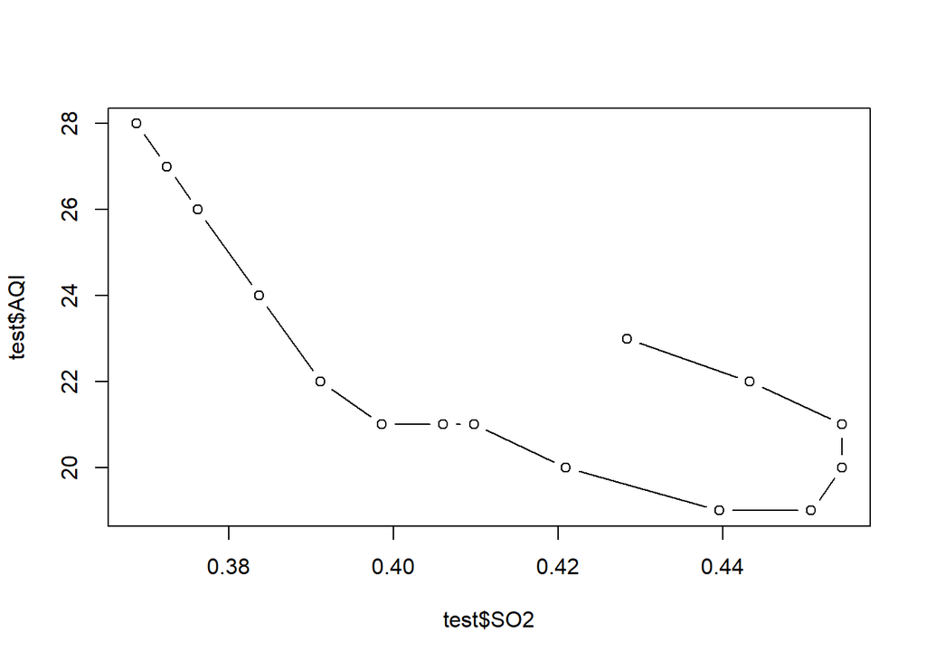

```r
par(mfrow=c(1,1))
plot(test$SO2, test$AQI, type="b", col="black")
```

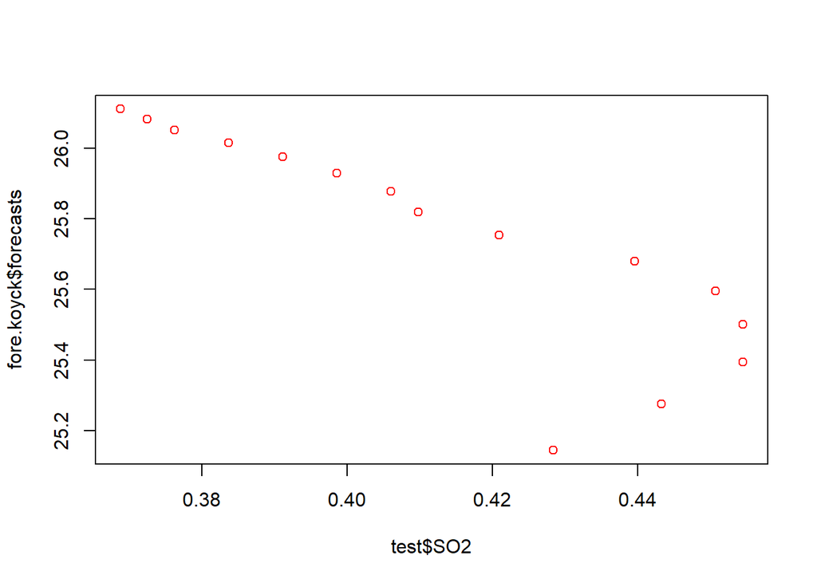

```r
plot(test$SO2, fore.koyck$forecasts,col="red")
```

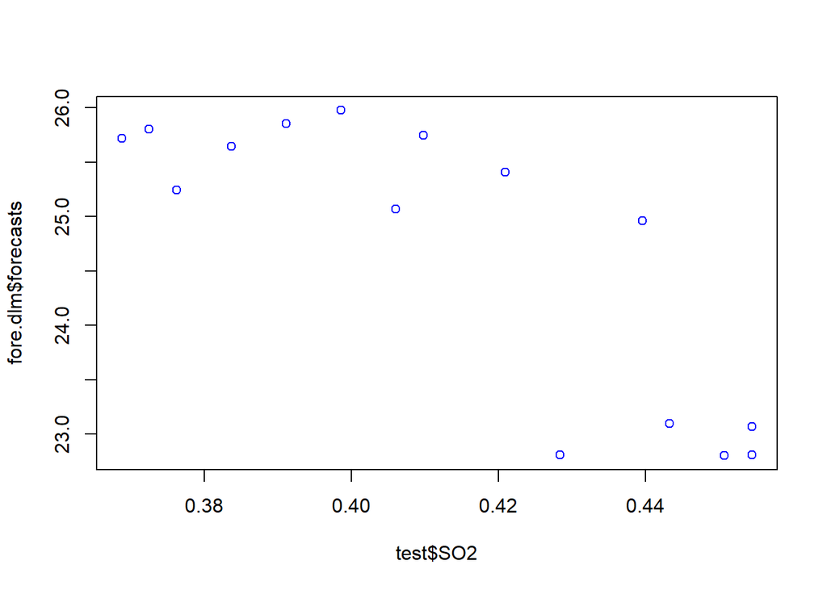

```r
plot(test$SO2, fore.dlm$forecasts,col="blue")
```

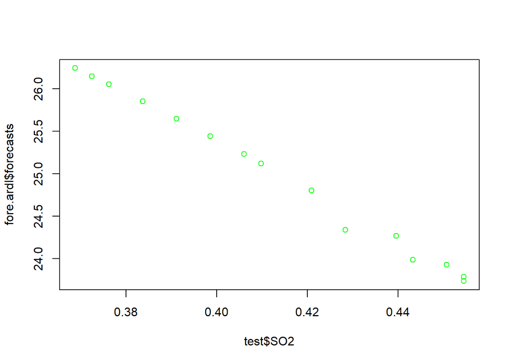

```r
plot(test$SO2, fore.ardl$forecasts,col="green")
```

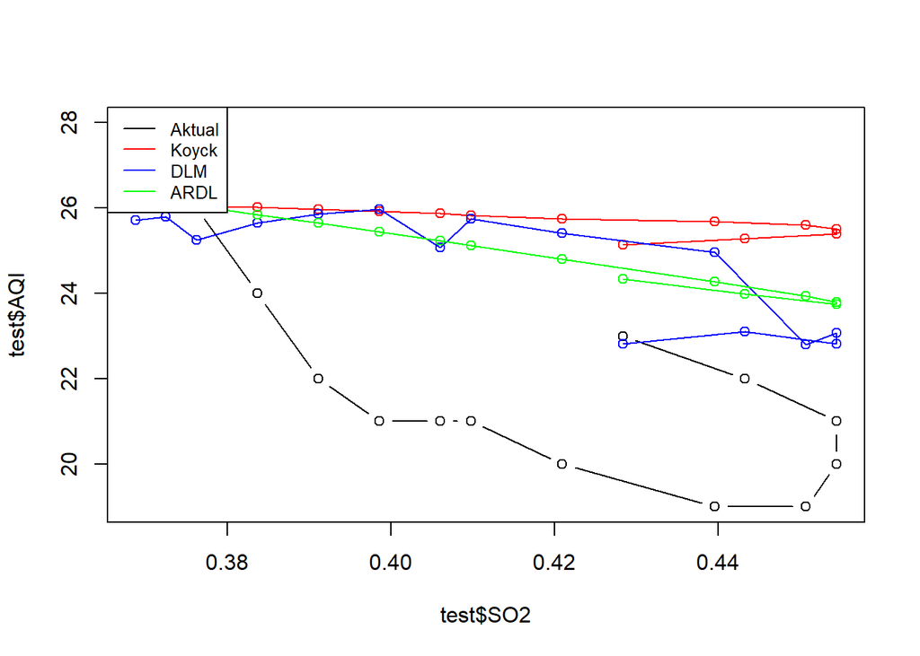

```r
plot(test$SO2, test$AQI, type="b", col="black")
points(test$SO2, fore.koyck$forecasts,col="red")
lines(test$SO2, fore.koyck$forecasts,col="red")
points(test$SO2, fore.dlm$forecasts,col="blue")
lines(test$SO2, fore.dlm$forecasts,col="blue")
points(test$SO2, fore.ardl$forecasts,col="green")
lines(test$SO2, fore.ardl$forecasts,col="green")
legend("topleft",c("Aktual", "Koyck","DLM", "ARDL"), lty=1, col=c("black","red","blue","green"), cex=0.8)
```

# Model Diagnostics

## Uji Non Autokorelasi

```r
#Breusch-Godfrey test
bgtest(model.ardl$model)
```

```
##
##  Breusch-Godfrey test for serial correlation of order up to 1
##
## data:  model.ardl$model
## LM test = 10.35, df = 1, p-value = 0.001295
```

```r
#Durbin-Watson test
dwtest(model.ardl$model)
```

```
##
##  Durbin-Watson test
##
## data:  model.ardl$model
## DW = 1.2104, p-value = 0.0003051
## alternative hypothesis: true autocorrelation is greater than 0
```

## Uji heterogenitas

```r
bptest(model.ardl$model)
```

```
##
##  studentized Breusch-Pagan test
##
## data:  model.ardl$model
## BP = 1.1986, df = 3, p-value = 0.7533
```

Berdasarkan uji Breusch-Pagan dihasilkan nilai p-value > alpha 5% sehingga tidak terjadi heteroskedastisitas pada model.

## Uji Normalitas

```r
ks.test(model.ardl$model$residuals, "pnorm")
```

```
##
##  Exact one-sample Kolmogorov-Smirnov test
##
## data:  model.ardl$model$residuals
## D = 0.10401, p-value = 0.545
## alternative hypothesis: two-sided
```